# Appendix S1. Linear regression models and non-linear population dynamics

# Model A: One species, logistic growth

Population growth over time in a single species is first modelled using a Beverton-Holt (discrete-time, logistic) model (Beverton and Holt (1957)), using an intra-specific competition coefficient for density-dependent growth (Hart and Marshall (2013)) - thus $\alpha$ = $1/K$.

$$N_{i,t+1} = \frac{r_i N_{i,t}}{1 +
\alpha_{ii} N_{i,t}}$$
Note that in this model, the system is at equilibrium when $N_{i,t+1} = N_{i,t}$, and therefore:
$$N^* =
N^*\frac{r_i}{1 + \alpha_{ii} N^*}$$

$$1 = \frac{r_i}{1 + \alpha_{ii} N^*}$$

$$N^* = \frac{r_i - 1}{\alpha_{ii}}$$

## Population dynamics simulation

We simulate population growth using $r_i = 1.67$ and $\alpha_{ii}$ = 0.00125, with an initial population size $N_{1,0} = 10$. This is implemented using the `disc_log` function from the `ecoevor` package https://github.com/jhpantel/ecoevoR.

```r
set.seed(42)
# Simulate initial species population growth
N1.0 <- 10
r1.0 <- 1.67
alpha.11 <- 0.00125
# Simulation of model for t time steps
t <- 30
N <- rep(NA, t)
N[1] <- N1.0
for (i in 2:t) {
    N[i] <- disc_log(r = r1.0, N0 = N[i - 1], alpha = alpha.11)
}
```

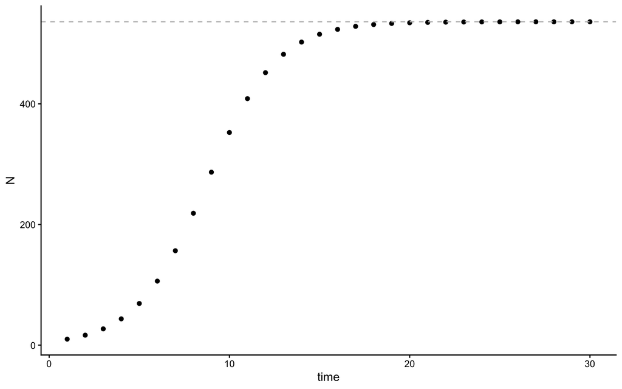

Population size over time for a discrete-time logistic growth model, with parameters $r_i$ = 1.67, $N_{1,0}$ = 10, and $\alpha_{11}$ = 0.00125.

## Linear statistical model

We fit the population time series data to a first-order auto-regressive model to predict $N_{t+1}$ as a function of $N_t$, and compare that to a linear regression. We use ln(N) after Ives (1995), as also discussed in Certain et al. (2018) and Olivença et al. (2021).

$$N_{t+1} = \beta_0 + \beta_1 N_t +
\epsilon_t$$

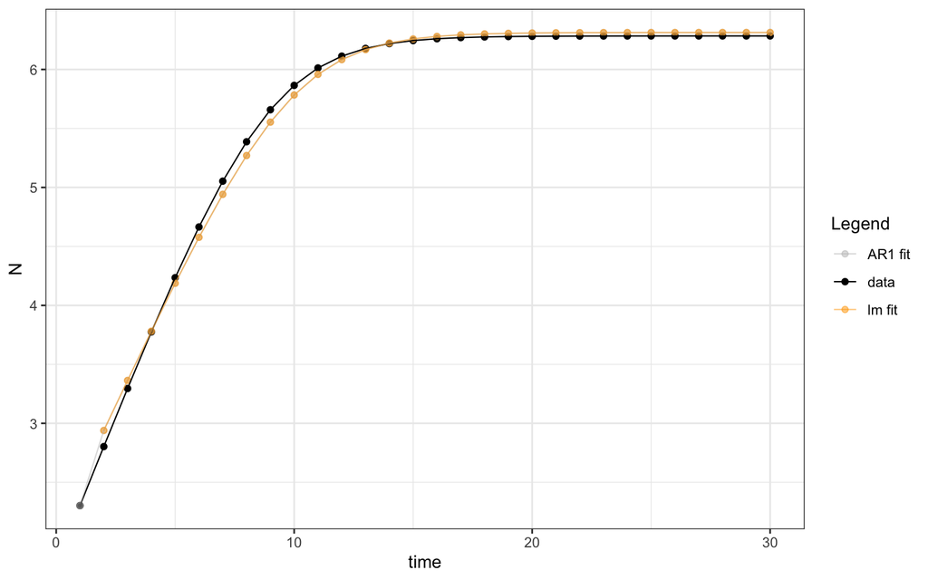

Population size over time (black line) with fitted values from a first-order autoregressive (grey) and linear regression (orange) model.

```r
# Fit the model
m.1.ar <- arima(x = log(N), order = c(1, 0, 0), include.mean = T, method = "CSS")
m.1.lm <- lm(log(dat$N[2:t]) ~ log(dat$N[1:(t - 1)]))
# plotting the series along with the fitted values
m.1.ar.fit <- log(N) - residuals(m.1.ar)
m.1.lm.fit <- log(dat$N[2:t]) - m.1.lm$resid
dat$ar1.fit <- m.1.ar.fit
dat$lm.fit <- NA
dat$lm.fit[2:t] <- m.1.lm.fit
```

The linear model is a good fit, and $N_{t+1}$ and $N_t$ are well-represented by a linear function:

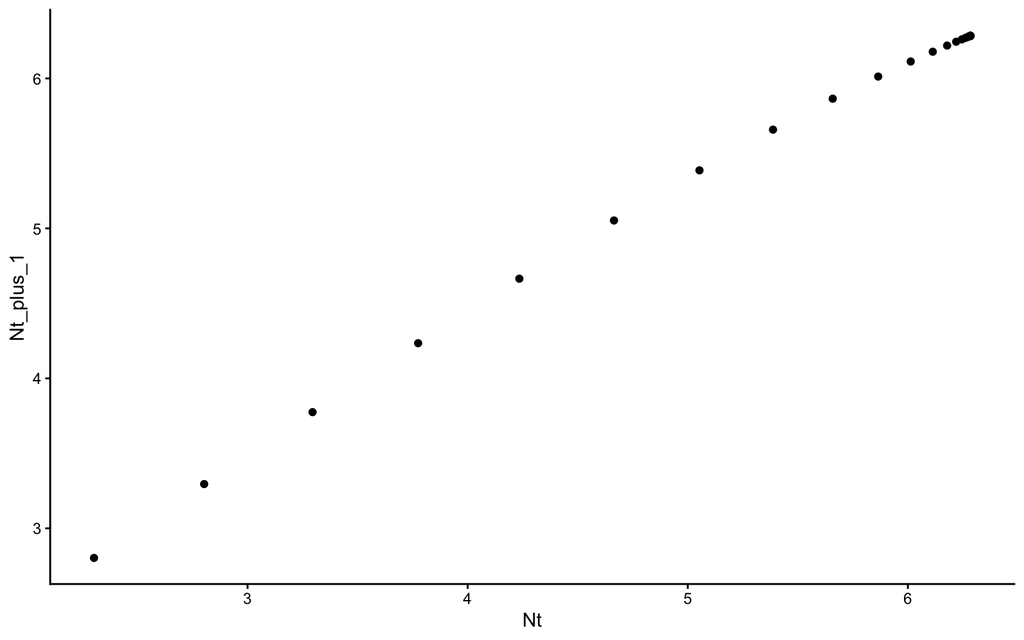

Population size (logarithm) at one time step $N_{t+1}$ as a function of log-population size in the previous time step $N_t$.

We also examine density dependence by plotting $\Delta N = N_{t+1} - N_t$ vs. $N_t$:

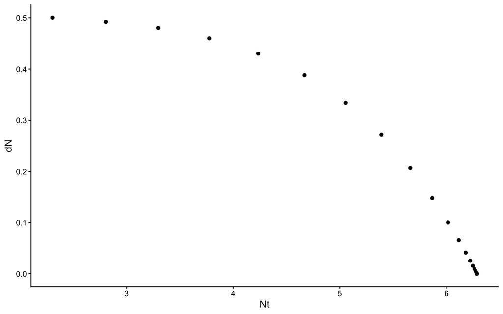

## Bayesian linear statistical model: HMSC

We can estimate the same model parameters using HMSC:

```r
# prepare data in HMSC format
Y <- as.matrix(log(dat$N[2:t]))
XData <- data.frame(x = log(dat$N[1:(t - 1)]))
m.1.hmsc <- Hmsc(Y = Y, XData = XData, XFormula = ~x)
# Bayesian model parameters
nChains <- 2
thin <- 5
samples <- 1000
transient <- 500 * thin
verbose <- 500 * thin
# sample MCMC
m.1.sample <- sampleMcmc(m.1.hmsc, thin = thin, sample = samples, transient = transient,
    nChains = nChains, verbose = verbose)
```

```r
m.post.hmsc <- convertToCodaObject(m.1.sample)
summary(m.post.hmsc$Beta)
```

```
#>
#> Iterations = 2505:7500
#> Thinning interval = 5
#> Number of chains = 2
#> Sample size per chain = 1000
#>
#> 1. Empirical mean and standard deviation for each variable,
#>    plus standard error of the mean:
#>
#>                                 Mean      SD  Naive SE Time-series SE
#> B[(Intercept) (C1), sp1 (S1)] 0.9887 0.06022 0.0013466      0.0013461
#> B[x (C2), sp1 (S1)]           0.8473 0.01055 0.0002358      0.0002421
#>
#> 2. Quantiles for each variable:
#>
#>                                 2.5%    25%   50%    75%  97.5%
#> B[(Intercept) (C1), sp1 (S1)] 0.8711 0.9476 0.990 1.0309 1.0983
#> B[x (C2), sp1 (S1)]           0.8274 0.8399 0.847 0.8543 0.8686
```

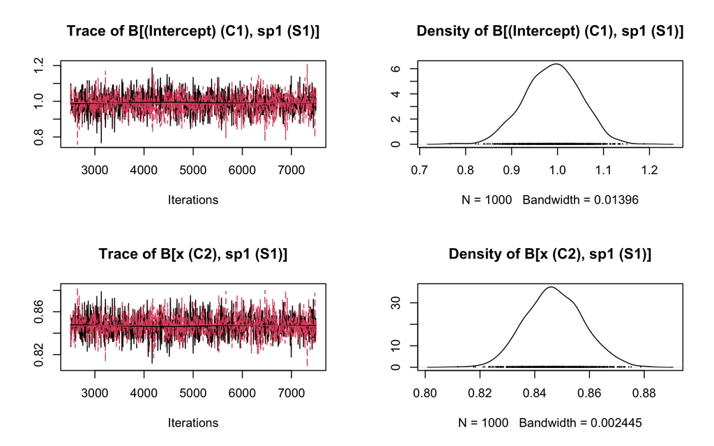

```r
plot(m.post.hmsc$Beta)
```

These estimates match well with those from the AR1 and linear model:

```r
# AR1 coefficients (recall that the intercept is the term below multipled by 1
# - phi1)
m.1.ar$coef
```

```
#>       ar1 intercept
#> 0.8473883 6.4763916
```

```r
m.1.ar$coef[2] * (1 - m.1.ar$coef[1])
```

```
#> intercept
#> 0.9883733
```

```r
# linear model
summary(m.1.lm)$coefficients[1:2, 1:2]
```

```
#>                        Estimate  Std. Error
#> (Intercept)           0.9883734 0.053842285
#> log(dat$N[1:(t - 1)]) 0.8473883 0.009454972
```

```r
# Bayesian estimates
summary(m.post.hmsc$Beta)$statistics[1:2, 1:2]
```

```
#>                                    Mean         SD
#> B[(Intercept) (C1), sp1 (S1)] 0.9887325 0.06022001
#> B[x (C2), sp1 (S1)]           0.8472922 0.01054677
```

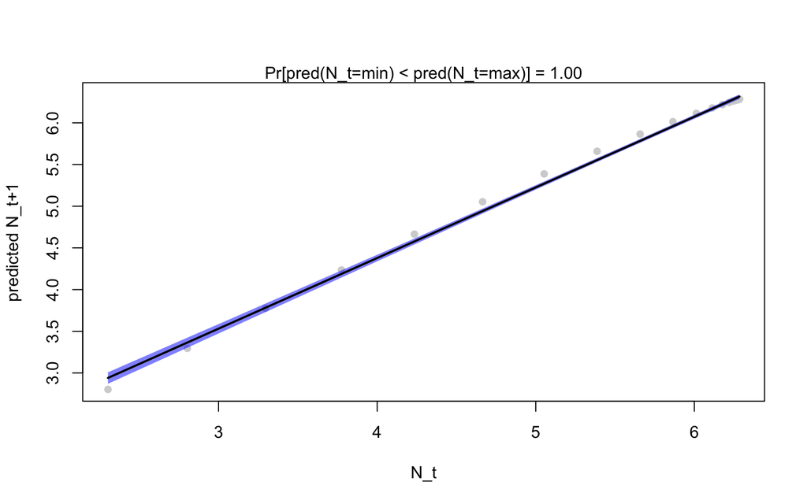

Observed (grey) and model-fit (blue) values for population size at time t (x-axis) and t+1 (y-axis) using HMSC.

```r
Gradient <- constructGradient(m.1.sample, focalVariable = "x", ngrid = 29)
predY <- predict(m.1.sample, Gradient = Gradient, expected = TRUE)
plotGradient(m.1.sample, Gradient, pred = predY, showData = T, measure = "Y", main = "",
    xlab = "N_t", ylab = "predicted N_t+1")
```

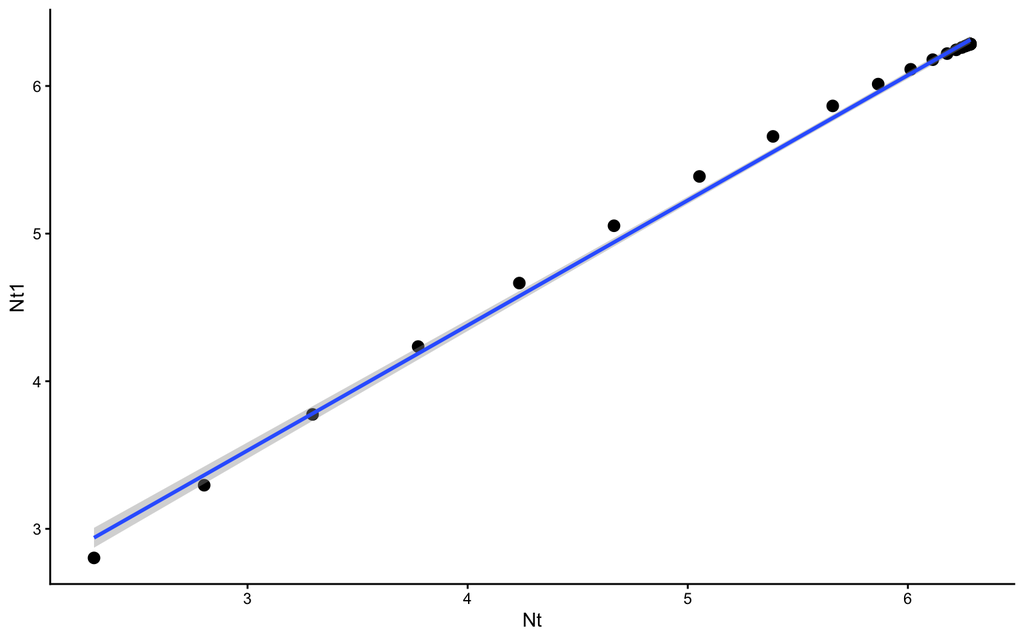

```r
lm_dat <- data.frame(cbind(log(dat$N[2:t]), log(dat$N[1:(t - 1)])))
colnames(lm_dat) <- c("Nt1", "Nt")
ggplot(lm_dat, aes(Nt, Nt1)) + stat_summary(fun.data = mean_cl_normal) + geom_smooth(method = "lm") +
    theme_classic()
```

## Conclusions

In this example, a first-order auto-regressive model works well, bypassing the need to estimate logistic growth parameters $r_i$ and $\alpha_{ii}$. The density-dependence dynamics ($\Delta N \sim f(N_t)$) show an overall declining trend over time. The Bayesian estimation implemented in HMSC gives good parameter estimates.

# Model B: One species, logistic growth, environmental covariate

We now consider using a linear model to analyze population growth when the species growth rate is impacted by a single environmental covariate.

## Growth depends on environment

First we add environment-dependent growth rate. The growth rate $r_i$ becomes:

$$r_i =
\hat{W}e^{-(E-x_{i,t})^2}$$

Here, $\hat{W}$ is the maximal population growth rate (set to 1.67 as above), $E$ is the local environmental trait optimum value, and $x_{i,t}$ is species *i* trait value at time *t*. We see that if $E = x_{i,t}$ then the growth rate is at the value $r$ = 1.67. Here, we begin with $E = x_{i,t} = 0.8$, then simulate the environment $E$ value fluctuating randomly over time, and finally use a linear model to fit $E$ as a covariate. We implement the simulation using the `disc_log_E` function from the `ecoevor` package.

```r
# Simulate initial species population growth with environment fluctuations
N1.0 <- 10
r1.0 <- 1.67
alpha.11 <- 0.00125
E.0 <- 0.8
x1.0 <- 0.8
# Simulation of model for t time steps
t <- 40
N <- rep(NA, t)
N[1] <- N1.0
E <- rep(NA, t)
E[1] <- E.0
for (i in 2:t) {
    N[i] <- disc_log_E(r = r1.0, N0 = N[i - 1], alpha = alpha.11, E = E[i - 1], x = x1.0)
    E[i] <- E[i - 1] + rnorm(1, 0, 0.1)
}
```

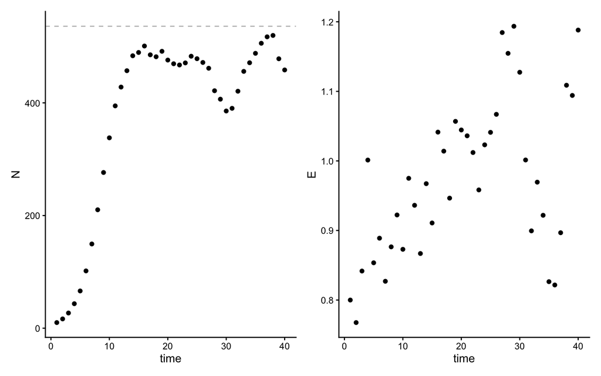

## Linear statistical model with environmental covariate

We now include environment $E$ as a covariate in the linear model:

$$N_{t} = \beta_0 + \beta_1 N_{t-1} +
\beta_2 E_{t-1}+ \epsilon_t$$

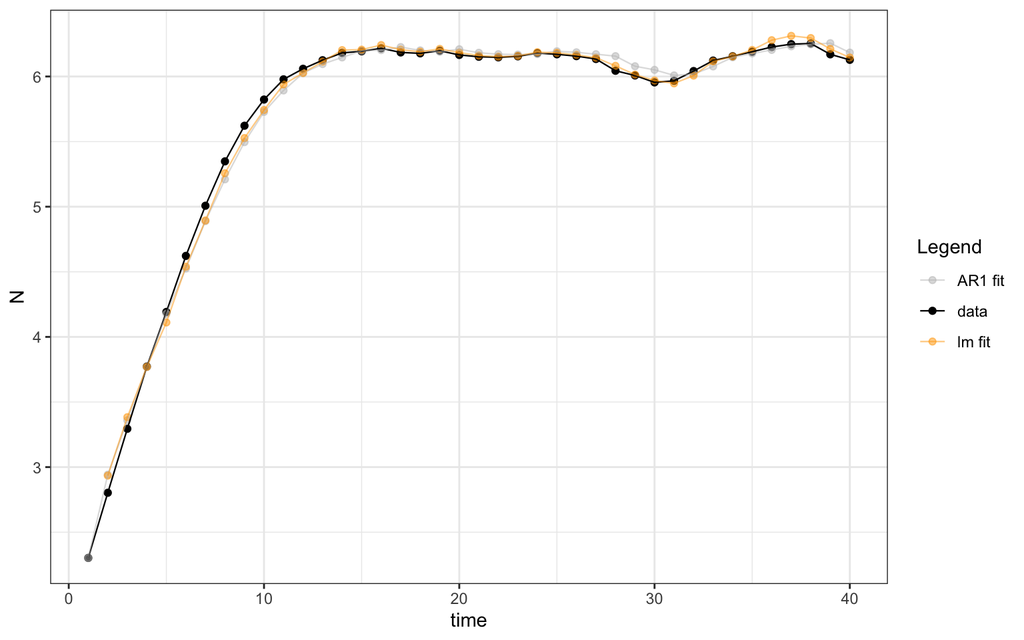

Population size over time (black line) with fitted values from a first-order autoregressive model (gray) and a linear model (orange).

```r
# Fit the model
m.2.ar <- arima(x = log(N), order = c(1, 0, 0), include.mean = T, method = "CSS",
    xreg = E)
m.2.lm <- lm(log(dat$N[2:t]) ~ log(dat$N[1:(t - 1)]) + log(E[1:(t - 1)]))
# plotting the series along with the fitted values
m.2.ar.fit <- log(N) - residuals(m.2.ar)
m.2.lm.fit <- log(dat$N[2:t]) - m.2.lm$resid
dat$ar2.fit <- m.2.ar.fit
dat$lm2.fit <- NA
dat$lm2.fit[2:t] <- m.2.lm.fit
```

The linear model is a good fit when including the environmental covariate. $N_{t+1}$ and $N_t$ can still be captured by a linear relationship. However we see that the relationship between $N_{t+1}$ and $E_t$ is non-linear.

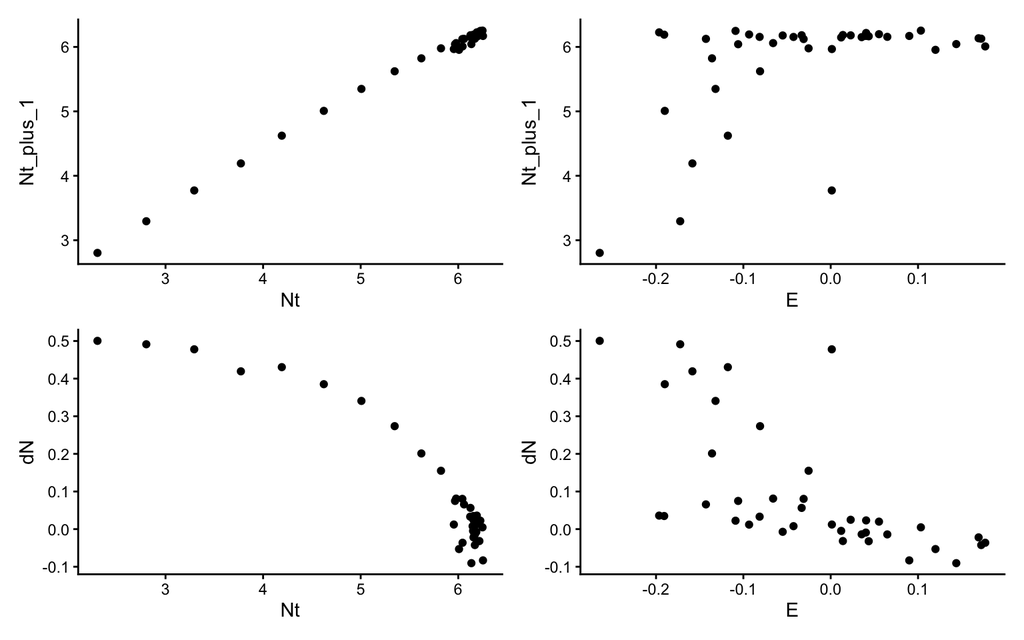

Population size (logarithm) at one time step $N_{t+1}$ as a function of log-population size in the previous time step $N_t$ and of environmental value $E_t$. Also shown are change in population size $\Delta N$ with population size and E.

This tells us that the lm is good for predictions, but not for inference (for capturing well the relationsip between the predictor and response variable). The use of linear relationships in JSDMs is discussed in (Ingram et al. 2020), and in many applications (e.g. (Erickson and Smith 2023)) quadratic terms are used, which create bell-shaped response curves that may better match species with optimal niches (as opposed to linear, monotonically increasing relationships between population size and environmental predictors). We thus include a quadratic term for $E_t$ to provide a better fit to the data.

```r
df <- data.frame(cbind(log(dat$N[2:t]), log(dat$N[1:(t - 1)]), E[1:(t - 1)], E[1:(t -
    1)]^2))
colnames(df) <- c("Nt1", "Nt", "E", "Esq")
m.2.lm <- lm(Nt1 ~ Nt + E + Esq, data = df)
```

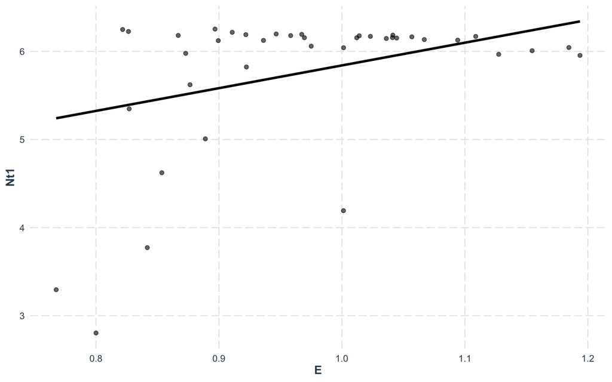

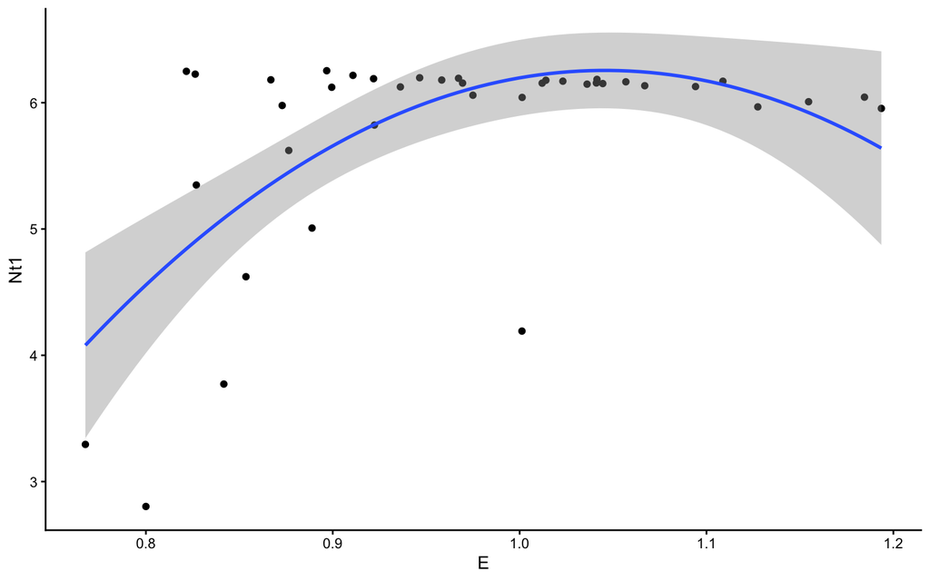

Population size (logarithm) at one time step $N_{t+1}$ as a function of environment E. Linear and quadratic fits are shown.

## Bayesian linear statistical model: HMSC

We can estimate the same model parameters using HMSC:

```r
# prepare data in HMSC format
Y <- as.matrix(log(dat$N[2:t]))
XData <- df
m.2.hmsc <- Hmsc(Y = Y, XData = XData, XFormula = ~Nt + E + Esq)
# Bayesian model parameters
nChains <- 2
thin <- 5
samples <- 1000
transient <- 500 * thin
verbose <- 500 * thin
# sample MCMC
m.2.sample <- sampleMcmc(m.2.hmsc, thin = thin, sample = samples, transient = transient,
    nChains = nChains, verbose = verbose)
```

```r
m2.post.hmsc <- convertToCodaObject(m.2.sample)
summary(m2.post.hmsc$Beta)
```

```
#>
#> Iterations = 2505:7500
#> Thinning interval = 5
#> Number of chains = 2
#> Sample size per chain = 1000
#>
#> 1. Empirical mean and standard deviation for each variable,
#>    plus standard error of the mean:
#>
#>                                  Mean      SD  Naive SE Time-series SE
#> B[(Intercept) (C1), sp1 (S1)] -0.1172 0.72629 0.0162404      0.0162433
#> B[Nt (C2), sp1 (S1)]           0.8521 0.01108 0.0002477      0.0002143
#> B[E (C3), sp1 (S1)]            2.5496 1.53081 0.0342299      0.0342367
#> B[Esq (C4), sp1 (S1)]         -1.4924 0.76626 0.0171341      0.0171372
#>
#> 2. Quantiles for each variable:
#>
#>                                  2.5%     25%     50%     75%   97.5%
#> B[(Intercept) (C1), sp1 (S1)] -1.5785 -0.5918 -0.1164  0.3659 1.33237
#> B[Nt (C2), sp1 (S1)]           0.8302  0.8448  0.8520  0.8594 0.87430
#> B[E (C3), sp1 (S1)]           -0.4942  1.5454  2.5787  3.5439 5.62748
#> B[Esq (C4), sp1 (S1)]         -3.0327 -1.9918 -1.5099 -0.9818 0.06678
```

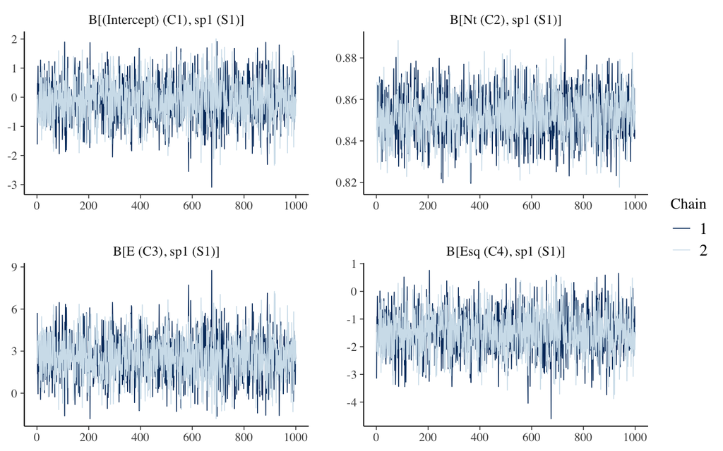

```r
bayesplot::mcmc_trace(m2.post.hmsc$Beta)
```

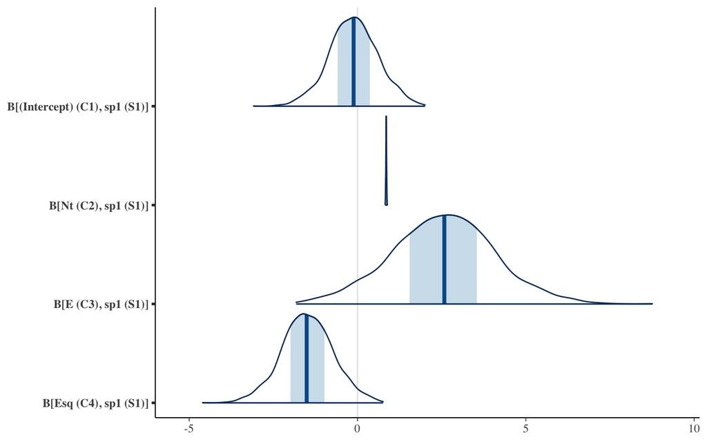

```r
bayesplot::mcmc_areas(m2.post.hmsc$Beta, area_method = c("equal height"))
```

These estimates match well with those from the AR1 and linear model:

```r
# AR1 coefficients (recall that the intercept is the term below multipled by 1
# - phi1)
m.2.ar$coef
```

```
#>         ar1   intercept           E
#>  0.83925564  6.29776167 -0.02674129
```

```r
m.2.ar$coef[2] * (1 - m.2.ar$coef[1])
```

```
#> intercept
#>   1.01233
```

```r
# linear model
summary(m.2.lm)$coefficients[1:4, 1:2]
```

```
#>               Estimate Std. Error
#> (Intercept) -0.1317811 0.63418671
#> Nt           0.8523506 0.01002202
#> E            2.5819242 1.33687286
#> Esq         -1.5113693 0.66907748
```

```r
# Bayesian estimates
summary(m2.post.hmsc$Beta)$statistics[1:4, 1:2]
```

```
#>                                     Mean         SD
#> B[(Intercept) (C1), sp1 (S1)] -0.1172053 0.72629078
#> B[Nt (C2), sp1 (S1)]           0.8521043 0.01107945
#> B[E (C3), sp1 (S1)]            2.5496453 1.53080925
#> B[Esq (C4), sp1 (S1)]         -1.4923591 0.76625968
```

We recall that the interpretation of the coefficients in an arimaX (arima with covariates) model is difficult. They do not give the impact on $N_t$ per unit increase in X as in a regression. So we do not interpret the causation implied by the coefficient in the arimaX model. In the regression model, we can see that $E$ has a positive impact on $N_t$.

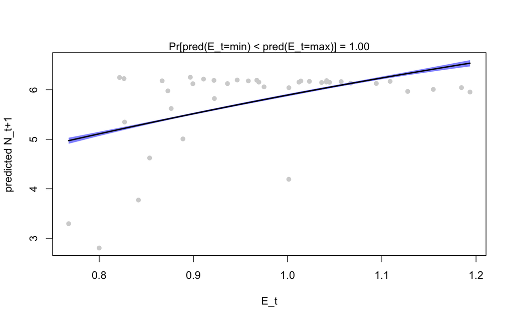

Observed (grey) and model-fit (blue) values for population size at time t+1 (y-axis) as a function of environment $E_t$ (x-axis).

```r
Gradient <- constructGradient(m.2.sample, focalVariable = "E", non.focalVariables = list(Nt = list(2),
    Esq = list(2)), ngrid = 39)
# Esq is manually constructed as gradient-produced E^2
Gradient$XDataNew$Esq <- Gradient$XDataNew$E^2
predY <- predict(m.2.sample, XData = Gradient$XDataNew, expected = TRUE)
plotGradient(m.2.sample, Gradient, pred = predY, showData = T, measure = "Y", main = "",
    xlab = "E_t", ylab = "predicted N_t+1")
```

## Conclusions

# Model C: Two species, logistic growth, competition

Here we investigate how a second species impacts the inference we can make from linear models.

## Interspecific competition

The growth equation for each species now becomes:

$$N_{i,t+1} = \frac{r_i N_{i,t}}{1 +
\alpha_{ii} N_{i,t} + \alpha_{ij} N_{j,t}}$$
We use a distinct growth rate for the 2nd species and introduce the interspecific interaction coefficient $\alpha_{ij}$. The simulation is generated using the `disc_LV_comp` function in the `ecoevor` package.

```r
# Initial conditions
N0 <- c(10, 10)
r <- c(1.67, 1.7)
alpha.11 <- 0.00125
alpha.22 <- 0.00125
alpha.12 <- 0.008
alpha.21 <- 0.008725
alpha <- matrix(c(alpha.11, alpha.21, alpha.12, alpha.22), nrow = 2, byrow = FALSE)
# make sure the interaction matrix is correct Simulation of model for t time
# steps
t <- 40
N <- array(NA, dim = c(t, 2))
N <- as.data.frame(N)
colnames(N) <- c("N1", "N2")
N[1, ] <- N0
for (i in 2:t) {
    N[i, ] <- disc_LV_comp(r = r, N0 = N[i - 1, ], alpha = alpha)
}
```

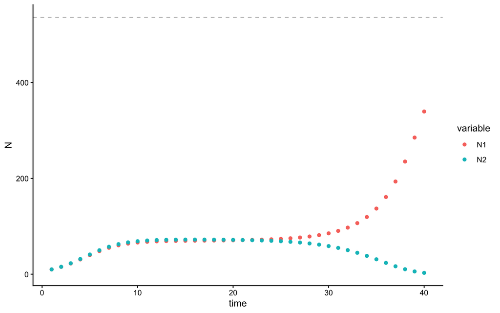

Population size over time for a discrete-time logistic growth model, with parameters $r_1$ = 1.67, $r_2$ = 1.7, $N_{i,0}$ = 10, $\alpha_{ii}$ = 0.00125, $\alpha_{12}$ = 0.008, and $\alpha_{21}$ = 0.008725.

## Linear statistical model with covariate for both species

We fit each species’ population time series to an arimaX and lm with population size of the others species as a covariate.

$$N_{1,t} = \beta_0 + \beta_1 N_{1,t-1} +
\beta_2 N_{2,t-1}+ \epsilon_t$$

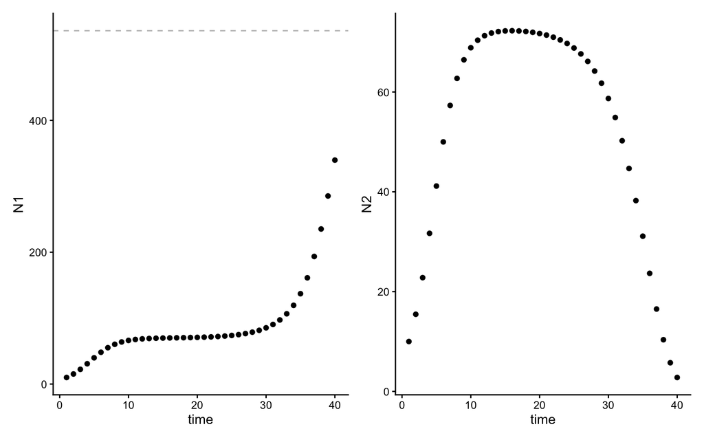

Population size over time for a discrete-time logistic growth model, with competition between 2 species ($N_1$ and $N_2$).

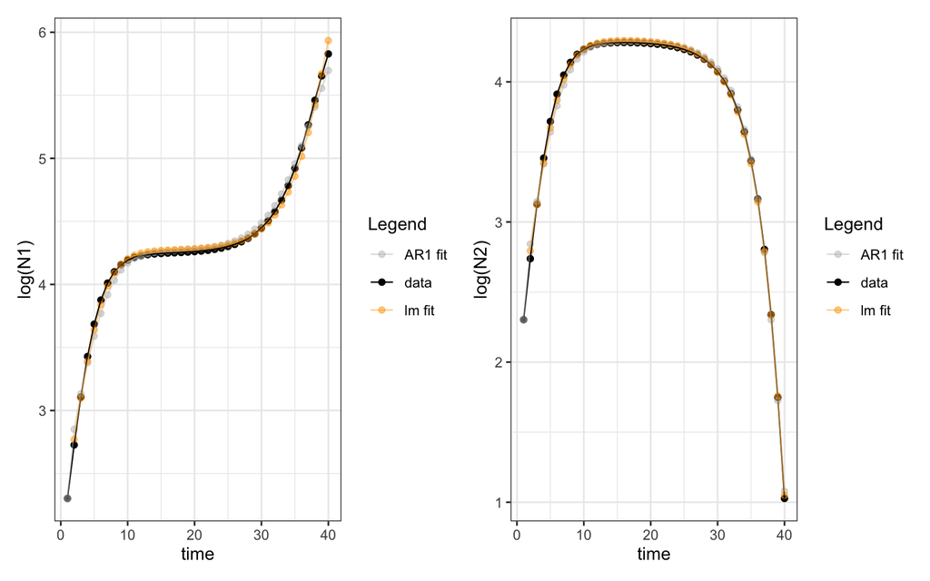

Population size over time (black line) with fitted values from a first-order autoregressive model (gray line) and from a linear model (orange line).

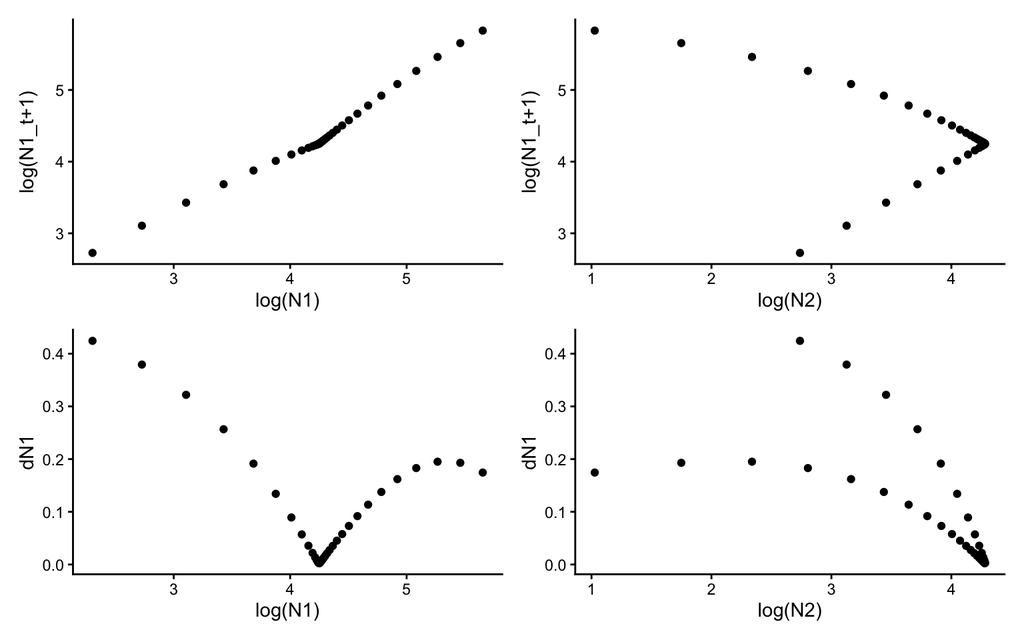

Population size (logarithm) in species 1 at one time step $N_{1,t+1}$ as a function of log-population size of Species 1 and Species 2 in the previous time step $N_t$. Also shown is the change in population size of Species 1 as a function of $N_t$ for both species.

```r
## Fit the model for Species 1
m.3.ar.n1 <- arima(x = log(N$N1), order = c(1, 0, 0), include.mean = T, method = "CSS",
    xreg = N$N2)
m.3.lm.n1 <- lm(log(dat$N1[2:t]) ~ log(dat$N1[1:(t - 1)]) + log(dat$N2[1:(t - 1)]))
# plotting the series along with the fitted values
m.3.ar.fit.n1 <- log(N$N1) - residuals(m.3.ar.n1)
m.3.lm.fit.n1 <- log(dat$N1[2:t]) - m.3.lm.n1$resid
dat$ar3.fit.n1 <- m.3.ar.fit.n1
dat$lm3.fit.n1 <- NA
dat$lm3.fit.n1[2:t] <- m.3.lm.fit.n1
## Species 2
m.3.ar.n2 <- arima(x = log(N$N2), order = c(1, 0, 0), include.mean = T, method = "CSS",
    xreg = N$N1)
m.3.lm.n2 <- lm(log(dat$N2[2:t]) ~ log(dat$N2[1:(t - 1)]) + log(dat$N1[1:(t - 1)]))
# plotting the series along with the fitted values
m.3.ar.fit.n2 <- log(N$N2) - residuals(m.3.ar.n2)
m.3.lm.fit.n2 <- log(dat$N2[2:t]) - m.3.lm.n2$resid
dat$ar3.fit.n2 <- m.3.ar.fit.n2
dat$lm3.fit.n2 <- NA
dat$lm3.fit.n2[2:t] <- m.3.lm.fit.n2
```

We can see that the population size of Species 2 does not have a linear relationship with that of Species 1.

```r
df <- data.frame(cbind(log(dat$N1[2:t]), log(dat$N1[1:(t - 1)]), log(dat$N2[1:(t -
    1)])))
colnames(df) <- c("Nt1", "N1", "N2")
m.3.lm <- lm(Nt1 ~ I(1/N1) + I(1/N2), data = df)
cor(df$Nt1, predict(m.3.lm))
```

```
#> [1] 0.9845708
```

```r
summary(m.3.lm)
```

```
#>
#> Call:
#> lm(formula = Nt1 ~ I(1/N1) + I(1/N2), data = df)
#>
#> Residuals:
#>      Min       1Q   Median       3Q      Max
#> -0.30952 -0.04467 -0.03442  0.03430  0.22447
#>
#> Coefficients:
#>             Estimate Std. Error t value Pr(>|t|)
#> (Intercept)   6.4056     0.1060   60.45  < 2e-16 ***
#> I(1/N1)     -12.2863     0.3774  -32.55  < 2e-16 ***
#> I(1/N2)       3.3309     0.2448   13.61 9.24e-16 ***
#> ---
#> Signif. codes:  0 '***' 0.001 '**' 0.01 '*' 0.05 '.' 0.1 ' ' 1
#>
#> Residual standard error: 0.1063 on 36 degrees of freedom
#> Multiple R-squared:  0.9694, Adjusted R-squared:  0.9677
#> F-statistic: 569.8 on 2 and 36 DF,  p-value: < 2.2e-16
```

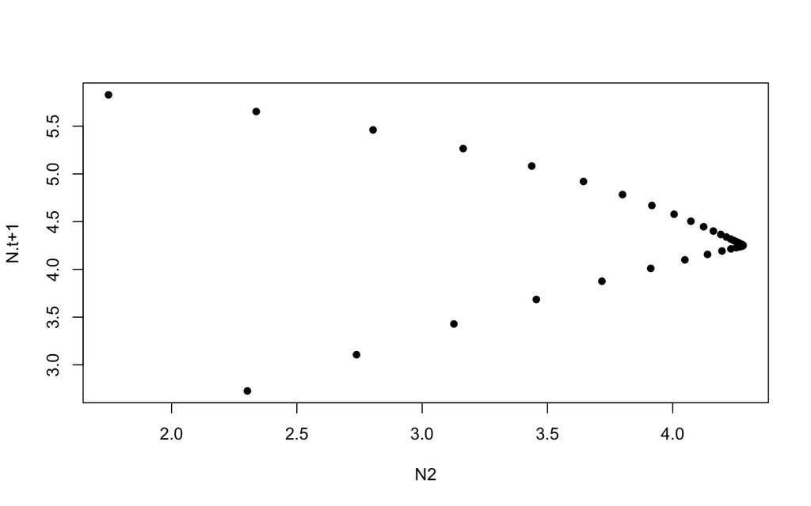

Population size (logarithm) in species 1 at one time step $N_{1,t+1}$ as a function of log-population size of Species 2 in the previous time step $N_t$.

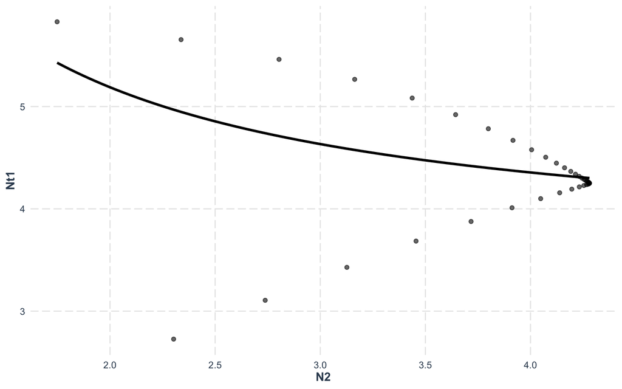

Linear model-predicted population size (logarithm) at one time step $N_{t+1}$ as a function of log-population size of the second species in the previous time step $N_t$. Fitted (line) and observed (points) values are shown.

In the concluding part, we will compare these linear model results to a Bayesian linear model.

```r
# prepare data for HMSC, run later
dat <- as.data.frame(log(N))
dat$time <- 1:t
df <- data.frame(dat[(2:t), -3])
Y <- as.matrix(df)
XData <- data.frame(dat[1:(t - 1), -3])
colnames(XData) <- c(paste0("n", 1:length(r)))
m.3a1.hmsc = Hmsc(Y = Y[, 1], XData = XData, XFormula = ~n1 + n2)
m.3a2.hmsc = Hmsc(Y = Y[, 2], XData = XData, XFormula = ~n1 + n2)
```

We can already see that the linear model provides a useful predictive fit to the data points, but the regression parameters cannot capture the complex relationship between species densities (neither does taking the inverse function help). The regression parameters can predict well the population size of the other species, but they are not informative for inference. This has been observed previously (Certain et al. (2018)), and non-linear least squares models (among others) are more often used to estimate parameters for dynamics resulting from these kinds of species interaction models (Kloppers and Greeff (2013); Mühlbauer et al. (2020); Olivença et al. (2021)). The inability of the linear models to reproduce the interaction coefficients is more clearly demonstrated in Certain et al. (2018). However, they do indicate that the slope of the linear model can reflect the direction of effect for the interacting species.

Instead of further exploring techniques to fit to time-series derived from non-linear competition processes, we look more closely at how HMSC manages to fit data emerging from competition dynamics and make inference about species interactions. Instead of estimating full interaction coefficients, or assuming sparse interactions, they instead assume that a reduced number of linear combinations of species abundances that are most relevant to determining future growth rates for species in the community can bypass the ‘curse of dimensionality’ problem. This is well presented in Ovaskainen et al. (2017). We apply that approach here.

## Bayesian linear statistical model: HMSC

We can fit the data to a linear model using HMSC, with latent variables to capture the species associations. These are implemented by including a random effect at the time level. For this analysis, we do not expect the impact of Species 1 and 2 that results from competition to vary over time - competition will always have negative impacts for species abundances. Our goal is to estimate the overall impact of species covariance across all of the time points. We do not estimate these impacts as a function of the lag in time points. In other words, we assume that each time point has random variance and that species may covary in their response at each time point. We do not consider that species covariance is a function of distance between sampled time points (see Ovaskainen and Abrego (2020), equation 5.9). We instead assume that site loadings $\eta$ are independent among the sampled time points.

```r
# prepare data in HMSC format
dat <- as.data.frame(log(N))
dat$time <- 1:t
df <- data.frame(dat[(2:t), -3])
Y <- as.matrix(df)
XData <- data.frame(dat[1:(t - 1), -3])
colnames(XData) <- c(paste0("n", 1:length(r)))
studyDesign = data.frame(sample = as.factor(1:(t - 1)))
studyDesign$sample <- as.factor(studyDesign$sample)
rL.sample = HmscRandomLevel(units = studyDesign$sample)
m.3.hmsc = Hmsc(Y = Y, XData = XData, XFormula = ~1, studyDesign = studyDesign, ranLevels = list(sample = rL.sample))
# Bayesian model parameters
nChains <- 2
thin <- 5
samples <- 1000
transient <- 500 * thin
verbose <- 500 * thin
# sample MCMC
m.3.sample <- sampleMcmc(m.3.hmsc, thin = thin, sample = samples, transient = transient,
    nChains = nChains, verbose = verbose)
```

```
#> Computing chain 1
#> Chain 1, iteration 2500 of 7500 (transient)
#> Chain 1, iteration 5000 of 7500 (sampling)
#> Chain 1, iteration 7500 of 7500 (sampling)
#> Computing chain 2
#> Chain 2, iteration 2500 of 7500 (transient)
#> Chain 2, iteration 5000 of 7500 (sampling)
#> Chain 2, iteration 7500 of 7500 (sampling)
```

```r
m3.post.hmsc <- convertToCodaObject(m.3.sample)
summary(m3.post.hmsc$Beta)
```

```
#>
#> Iterations = 2505:7500
#> Thinning interval = 5
#> Number of chains = 2
#> Sample size per chain = 1000
#>
#> 1. Empirical mean and standard deviation for each variable,
#>    plus standard error of the mean:
#>
#>                              Mean      SD Naive SE Time-series SE
#> B[(Intercept) (C1), N1 (S1)] 4.34 0.09341 0.002089       0.002039
#> B[(Intercept) (C1), N2 (S2)] 3.81 0.11431 0.002556       0.002555
#>
#> 2. Quantiles for each variable:
#>
#>                               2.5%   25%   50%   75% 97.5%
#> B[(Intercept) (C1), N1 (S1)] 4.154 4.279 4.341 4.401 4.511
#> B[(Intercept) (C1), N2 (S2)] 3.581 3.731 3.810 3.887 4.035
```

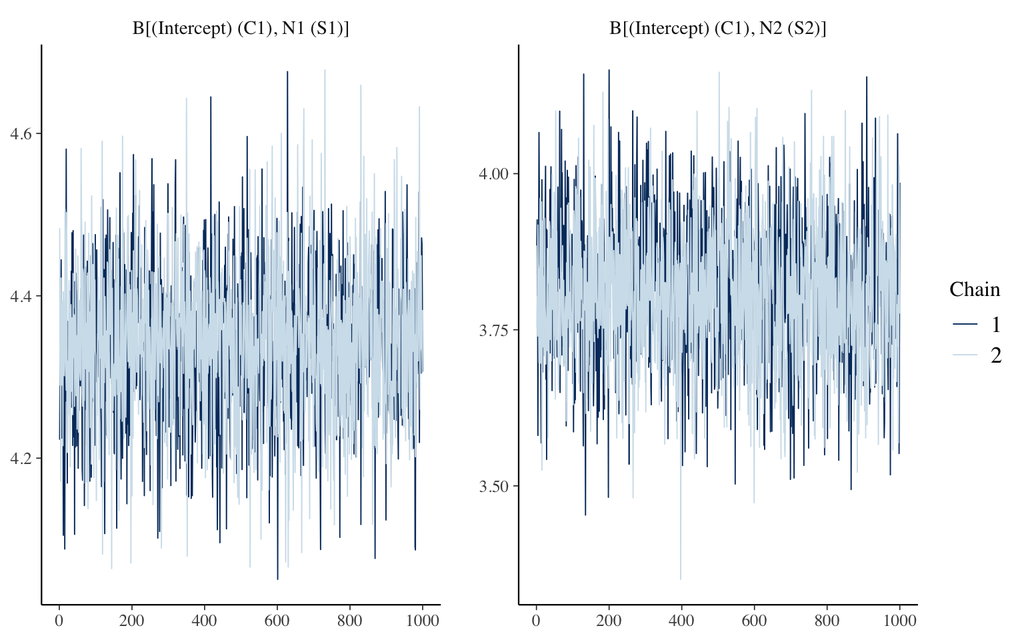

```r
bayesplot::mcmc_trace(m3.post.hmsc$Beta)
```

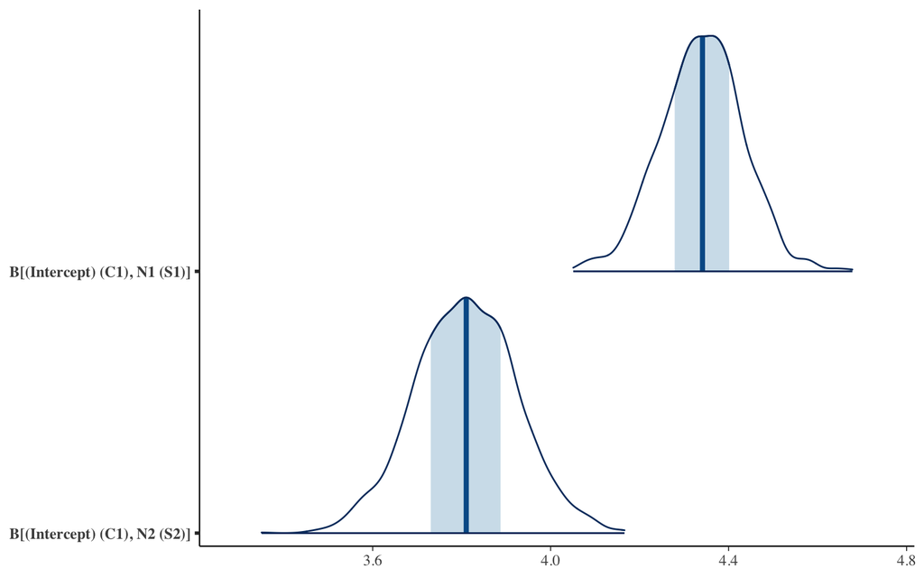

```r
bayesplot::mcmc_areas(m3.post.hmsc$Beta, area_method = c("equal height"))
```

Now we look at the estimates for the species associations:

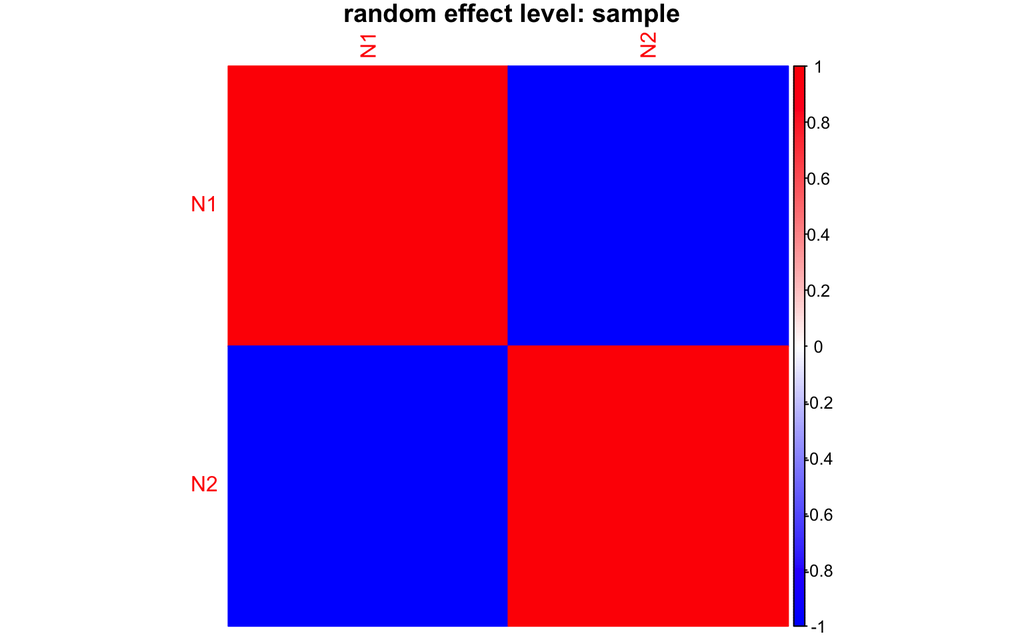

```r
OmegaCor = computeAssociations(m.3.sample)
supportLevel = 0.95
toPlot = ((OmegaCor[[1]]$support > supportLevel) + (OmegaCor[[1]]$support < (1 -
    supportLevel)) > 0) * OmegaCor[[1]]$mean
corrplot::corrplot(toPlot, method = "color", col = colorRampPalette(c("blue", "white",
    "red"))(200), title = paste("random effect level:", m.3.sample$rLNames[1]), mar = c(0,
    0, 1, 0))
```

```r
# AR1 coefficients (recall that the intercept is the term below multipled by 1
# - phi1)
m.3.ar.n1$coef
```

```
#>         ar1   intercept        N$N2
#>  0.79696422  5.69840618 -0.01881979
```

```r
m.3.ar.n1$coef[2] * (1 - m.3.ar.n1$coef[1])
```

```
#> intercept
#>   1.15698
```

```r
# linear model
summary(m.3.lm.n1)$coefficients[1:3, 1:2]
```

```
#>                          Estimate  Std. Error
#> (Intercept)             0.9839341 0.053084123
#> log(dat$N1[1:(t - 1)])  0.9201864 0.009157214
#> log(dat$N2[1:(t - 1)]) -0.1443693 0.008777527
```

```r
# Bayesian estimates
summary(m3.post.hmsc$Beta)$statistics[1:2, 1:2]
```

```
#>                                  Mean         SD
#> B[(Intercept) (C1), N1 (S1)] 4.340340 0.09340565
#> B[(Intercept) (C1), N2 (S2)] 3.809673 0.11430500
```

The HMSC model correctly shows the negative association between the species (shown here as correlations - JSDM CHapter 7 tells us the intra-specific correlation is always 1).

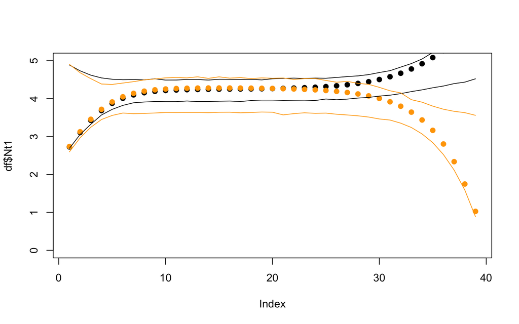

To show that the HMSC model correctly allocates variance to the contributing components of the model (here environment, intra-specific and interspecific density-dependence, implemented as temporal random effects), we simulate a new example where the only difference between species is the $\alpha_{ij}$.

```r
# Initial conditions
N0 <- c(10, 10)
r <- c(1.7, 1.7)
alpha.11 <- 0.01
alpha.22 <- 0.01
alpha.12 <- 0.005
alpha.21 <- 0.01
alpha <- matrix(c(alpha.11, alpha.21, alpha.12, alpha.22), nrow = 2, byrow = FALSE)  # careful to make sure you have correct interaction matrix
# Simulation of model for t time steps
t <- 40
N <- array(NA, dim = c(t, 2))
N <- as.data.frame(N)
colnames(N) <- c("N1", "N2")
N[1, ] <- N0
for (i in 2:t) {
    N[i, ] <- disc_LV_comp(r = r, N0 = N[i - 1, ], alpha = alpha)
}
```

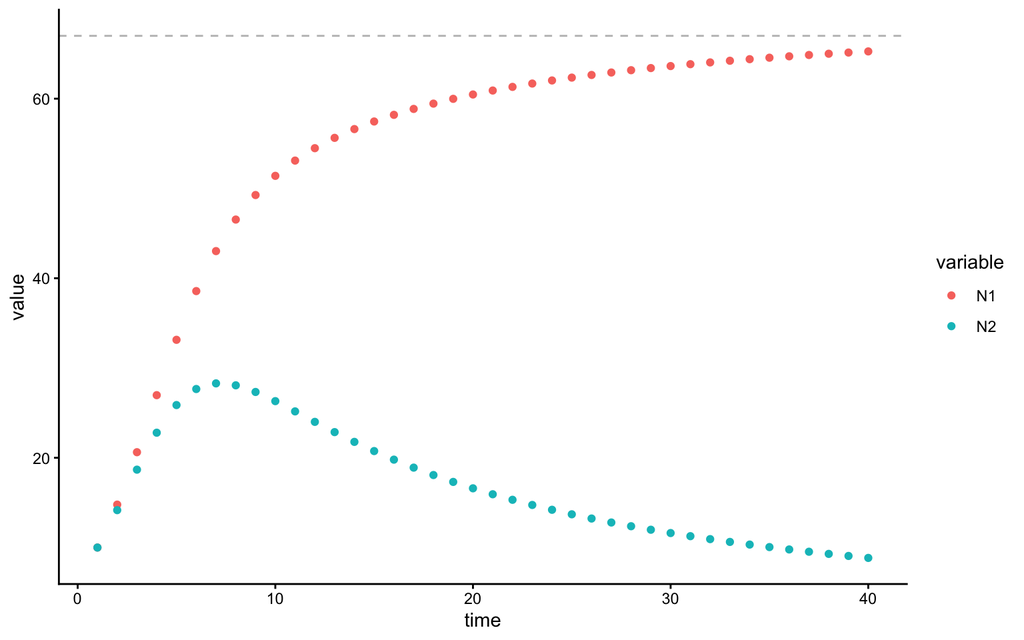

Population size over time for a discrete-time logistic growth model with competition, with parameters $r_1 = r_2$ = 1.7, $N_{i,0}$ = 10, $\alpha_{ii}$ = 0.01, $\alpha_{12}$ = 0.005, and $\alpha_{21}$ = 0.01.

```r
# Plot simulation: ggplot
dat <- as.data.frame(cbind(N$N1, N$N2))
colnames(dat) <- c("N1", "N2")
dat$time <- 1:t
df <- data.frame(cbind(log(dat$N1[2:t]), log(dat$N2[2:t])))
colnames(df) <- c("Nt1", "Nt2")
# prepare data in HMSC format
Y <- as.matrix(cbind(df$Nt1, df$Nt2))
XData <- data.frame(cbind(log(dat$N1[1:(t - 1)]), log(dat$N2[1:(t - 1)])))
studyDesign = data.frame(sample = as.factor(1:(t - 1)))
studyDesign$sample <- as.factor(studyDesign$sample)
rL.sample = HmscRandomLevel(units = studyDesign$sample)
m.4.hmsc = Hmsc(Y = Y, XData = XData, XFormula = ~1, studyDesign = studyDesign, ranLevels = list(sample = rL.sample))
# Bayesian model parameters
nChains <- 2
thin <- 5
samples <- 1000
transient <- 500 * thin
verbose <- 500 * thin
# sample MCMC
m.4.sample <- sampleMcmc(m.4.hmsc, thin = thin, sample = samples, transient = transient,
    nChains = nChains, verbose = verbose)
```

```
#> Computing chain 1
#> Chain 1, iteration 2500 of 7500 (transient)
#> Chain 1, iteration 5000 of 7500 (sampling)
#> Chain 1, iteration 7500 of 7500 (sampling)
#> Computing chain 2
#> Chain 2, iteration 2500 of 7500 (transient)
#> Chain 2, iteration 5000 of 7500 (sampling)
#> Chain 2, iteration 7500 of 7500 (sampling)
```

```r
m4.post.hmsc <- convertToCodaObject(m.4.sample)
summary(m4.post.hmsc$Beta)
```

```
#>
#> Iterations = 2505:7500
#> Thinning interval = 5
#> Number of chains = 2
#> Sample size per chain = 1000
#>
#> 1. Empirical mean and standard deviation for each variable,
#>    plus standard error of the mean:
#>
#>                                Mean      SD Naive SE Time-series SE
#> B[(Intercept) (C1), sp1 (S1)] 3.974 0.05288 0.001183       0.001153
#> B[(Intercept) (C1), sp2 (S2)] 2.767 0.06124 0.001369       0.001428
#>
#> 2. Quantiles for each variable:
#>
#>                                2.5%   25%   50%   75% 97.5%
#> B[(Intercept) (C1), sp1 (S1)] 3.867 3.939 3.975 4.009 4.077
#> B[(Intercept) (C1), sp2 (S2)] 2.646 2.726 2.766 2.808 2.884
```

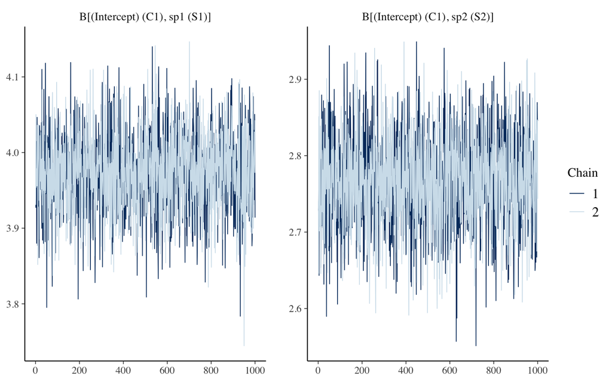

```r
bayesplot::mcmc_trace(m4.post.hmsc$Beta)
```

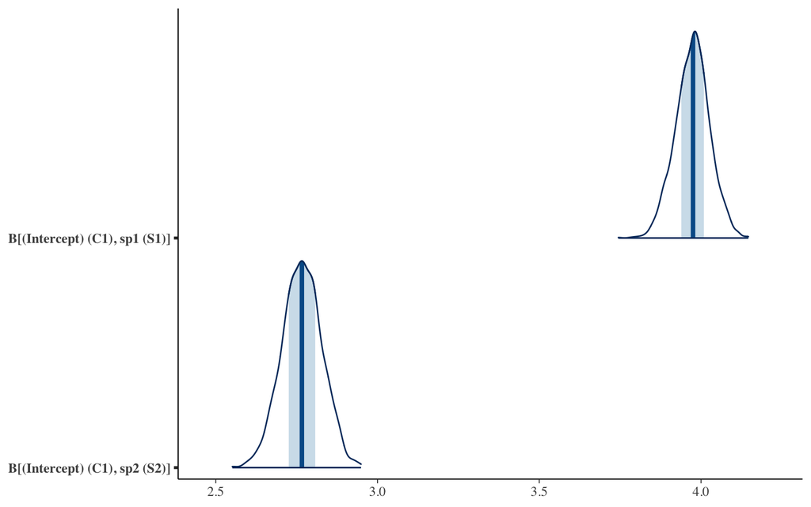

```r
bayesplot::mcmc_areas(m4.post.hmsc$Beta, area_method = c("equal height"))
```

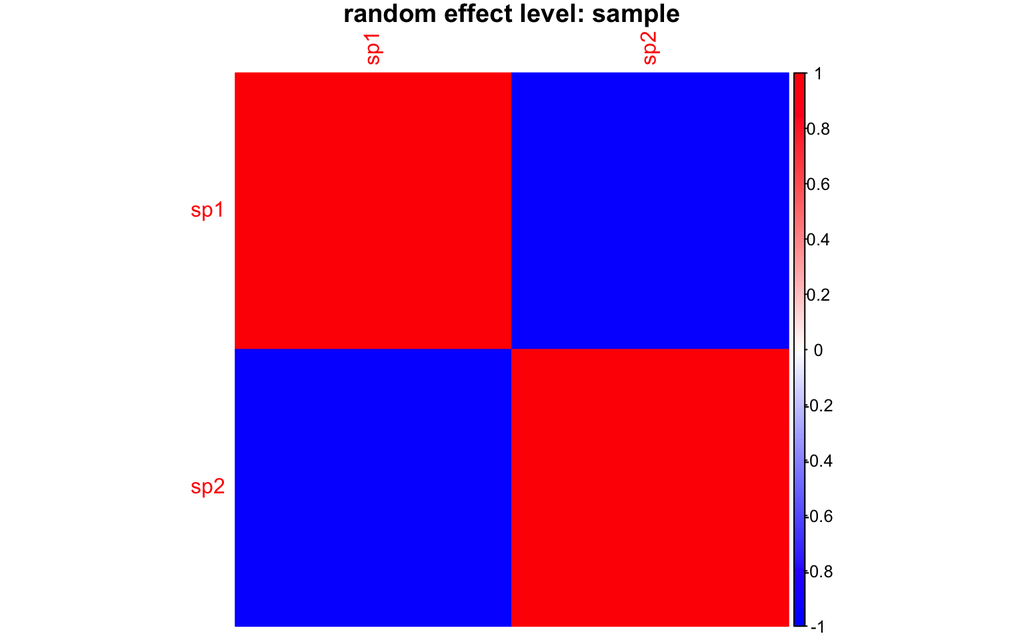

```r
OmegaCor = computeAssociations(m.4.sample)
supportLevel = 0.95
toPlot = ((OmegaCor[[1]]$support > supportLevel) + (OmegaCor[[1]]$support < (1 -
    supportLevel)) > 0) * OmegaCor[[1]]$mean
corrplot::corrplot(toPlot, method = "color", col = colorRampPalette(c("blue", "white",
    "red"))(200), title = paste("random effect level:", m.4.sample$rLNames[1]), mar = c(0,
    0, 1, 0))
```

The HMSC model correctly shows the negative association between the species (shown here as correlations - JSDM Chapter 7 tells us the intra-specific correlation is always 1).

```r
# explanatory power
preds = computePredictedValues(m.4.sample)
```

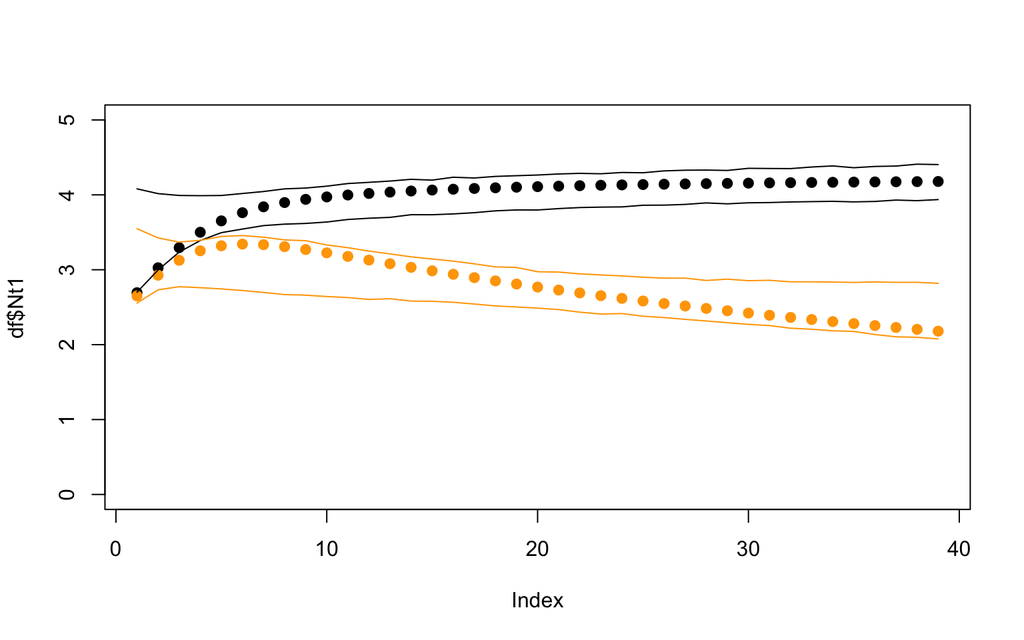

In the concluding part, we will compare Bayesian linear model results.

```r
# prepare data for HMSC, run later
m.4a1.hmsc = Hmsc(Y = Y[, 1], XData = XData, XFormula = ~X1 + X2)
m.4a2.hmsc = Hmsc(Y = Y[, 2], XData = XData, XFormula = ~X1 + X2)
```

The residual associations should not be interpreted as interaction coefficients, but rather used for prediction. We can see here they are effective for this (shown above is the observed and model-predicted 95% highest probability density interval - HPDI).

## Conclusions

# Model D: Species growth, competition, with environmental change

## Environmental covariate + other elements

In this example, the local environmental optimum trait value $E = 0.8$, and Species 1 $x_1 = 0.6$, while $x_2 = 0.8$. The simulation is generated using the `disc_LV_E` function in the `ecoevor` package.

```r
# Initial conditions
N0 <- c(10, 10)
r <- c(1.7, 1.7)
alpha.11 <- 0.01
alpha.22 <- 0.01
alpha.12 <- 0.005
alpha.21 <- 0.01
alpha <- matrix(c(alpha.11, alpha.21, alpha.12, alpha.22), nrow = 2, byrow = FALSE)
E.0 <- 0.8
x <- c(0.6, 0.8)
# Simulation of model for t time steps
t <- 40
N <- array(NA, dim = c(t, length(N0)))
N <- as.data.frame(N)
colnames(N) <- paste0("N", 1:length(N0))
N[1, ] <- N0
E <- rep(NA, t)
E[1] <- E.0
for (i in 2:t) {
    N[i, ] <- disc_LV_E(r = r, N0 = N[i - 1, ], alpha = alpha, E = E[i - 1], x = x)
    E[i] <- E[i - 1] + rnorm(1, 0, 0.1)
}
```

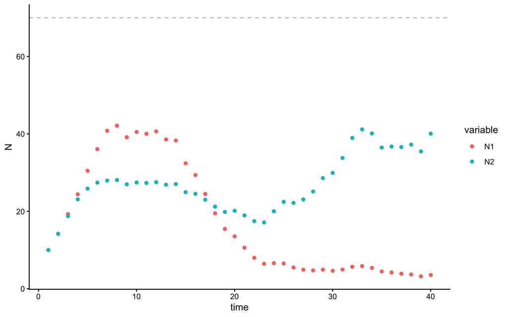

Population size over time for a discrete-time logistic growth model with competition and a changing environment, with parameters $r_1 = r_2$ = 1.7, $N_{i,0}$ = 10, $\alpha_{ii}$ = 0.01, $\alpha_{12}$ = 0.005, and $\alpha_{21}$ = 0.01.